# Relatório de Unidade - Autoavaliação UFRPE 2019 (UACSA)

# 1 INTRODUÇÃO

Este relatório apresenta as respostas dos discentes, docentes e técnicos da Unidade Acadêmica do Cabo de Santo Agostinho (UACSA), referente à autoavaliação 2019 da Universidade Federal Rural de Pernambuco (UFRPE), conduzida pela Comissão Própria de Avaliação (CPA). Neste ano foram contemplados dois eixos avaliativos: Planejamento e Avaliação Institucional e Desenvolvimento Institucional.

Esta avaliação foi feita a partir de questionários online, disponibilizados de forma voluntária aos discentes, docentes e técnicos da instituição, no período de 23 de abril a 29 de julho de 2019. Maiores detalhes sobre a metodologia de autoavaliação podem ser encontrados no 2º Relatório Parcial de Autoavaliação Institucional (ANO-BASE 2019), disponível no site da [CPA/UFRPE](http://cpa.ufrpe.br/br/relatorio-de-autoavaliacao-institucional/).

Note que este relatório apresenta os resultados da avaliação da UFRPE *como um todo* sob o ponto de vista dos membros desta unidade; sendo assim, não pode ser interpretado como uma avaliação da unidade propriamente dita.

# 2 PANORAMA

Dentre os membros da comunidade acadêmica desta unidade aptos a participar da avaliação, 33.84% dos estudantes responderam ao questionário (353 de 1043), 80% dos docentes responderam ao questionário (60 de 75), e 79.55% dos técnicos responderam ao questionário (35 de 44).

Os gráficos a seguir apresentam os resultados da avaliação de alguns itens pré-selecionados: Ações de Planejamento de Cursos e Utilização dos Resultados da Autoavaliação Institucional no Planejamento de Cursos, além da atuação da UFRPE na promoção do desenvolvimento econômico e social, da sustentabilidade, da igualdade étnico-racial, e na valorização da diversidade.

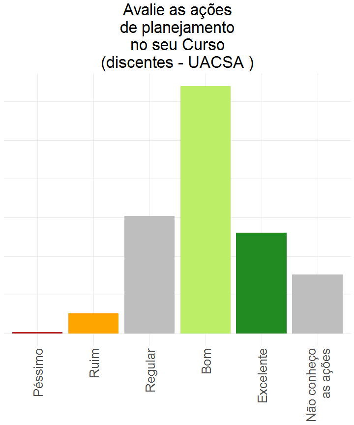

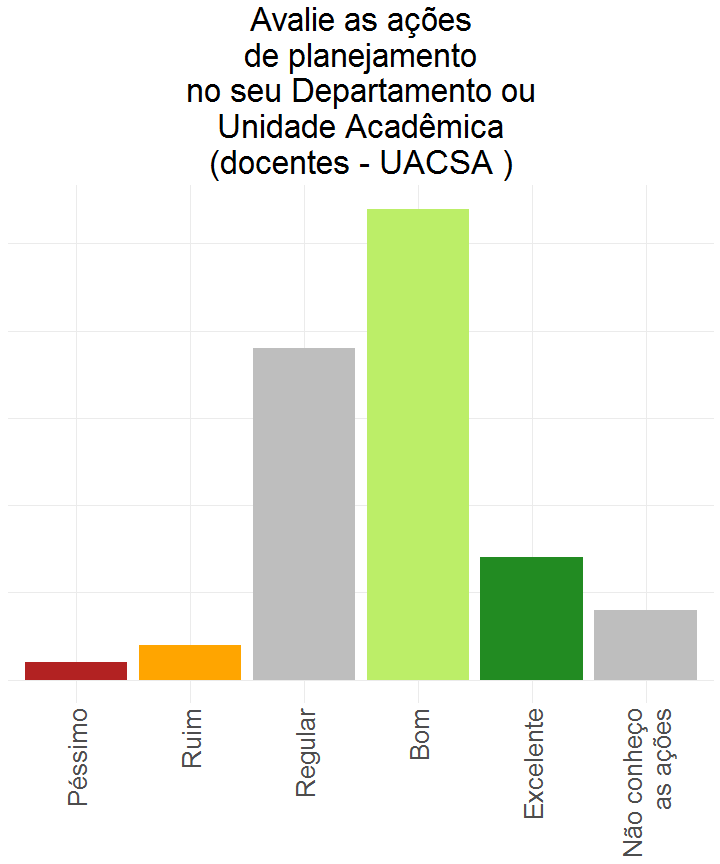

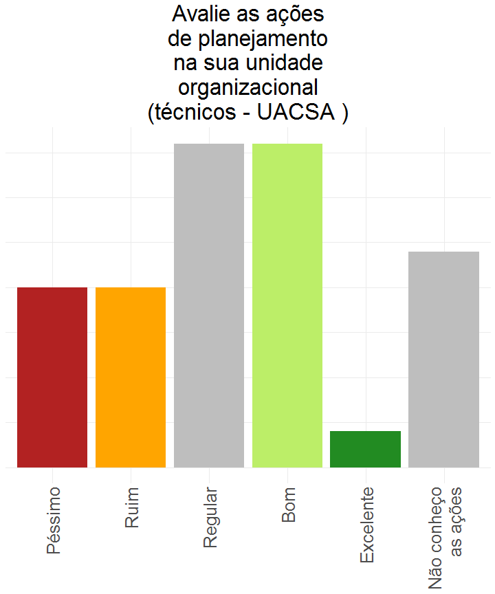

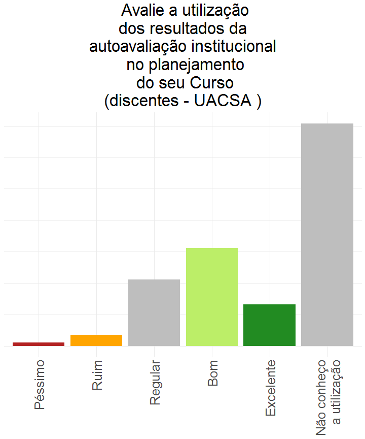

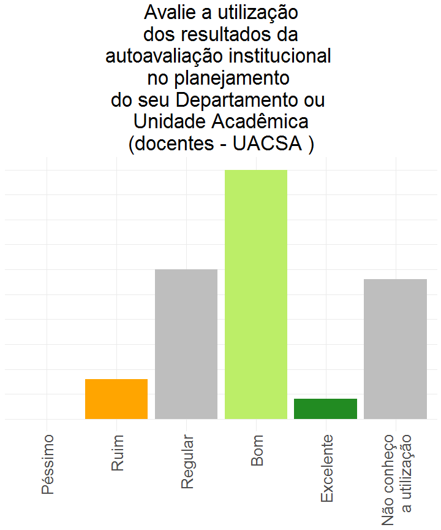

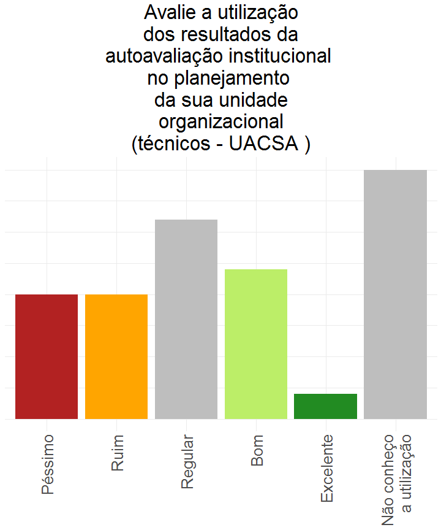

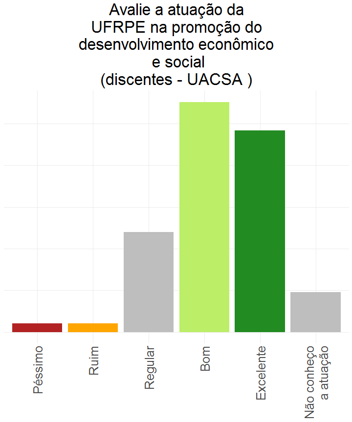

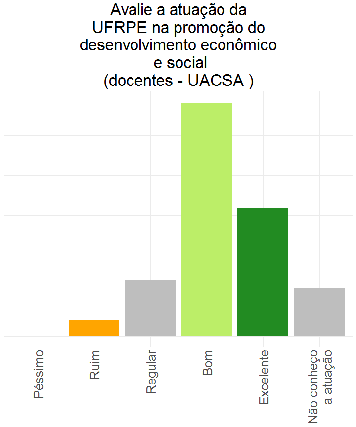

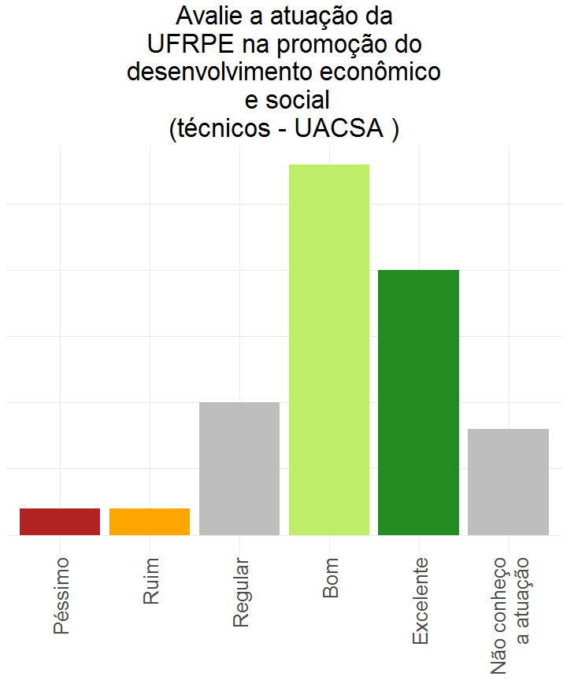

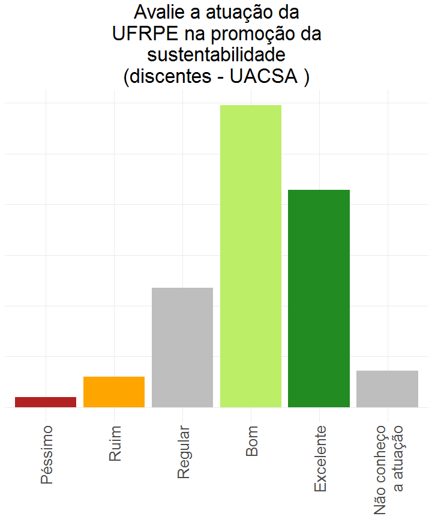

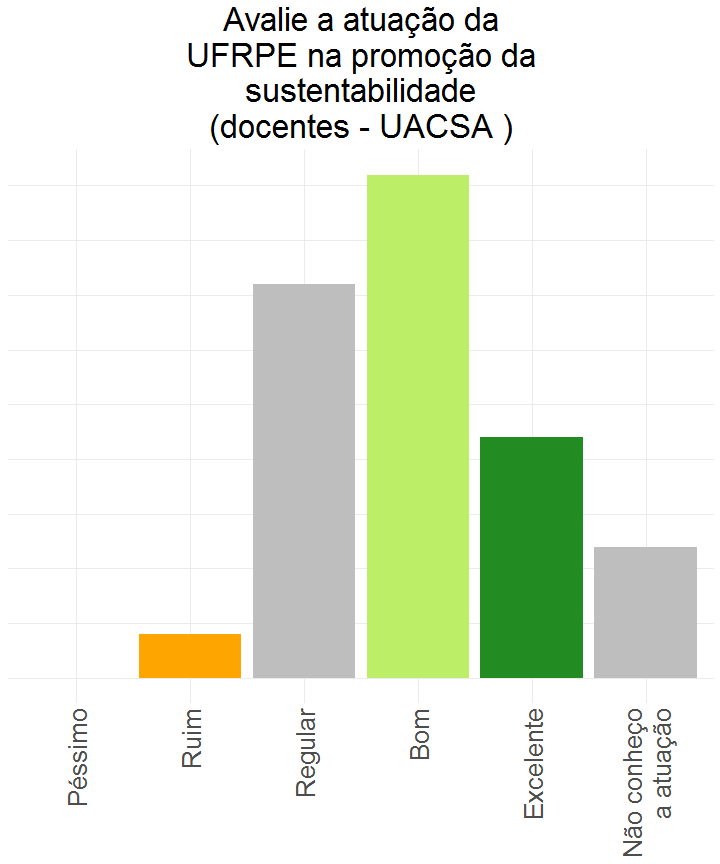

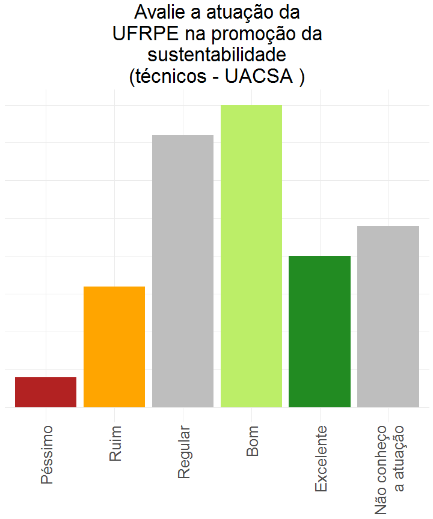

[6 more figures not shown]

# 3 DESTAQUES - PLANEJAMENTO E AVALIAÇÃO INSTITUCIONAL

Esta seção apresenta os resultados com maiores e menores médias numéricas referentes à avaliação do Planejamento e da Avaliação Institucional da UFRPE, conforme respondido pelos integrantes da Unidade Acadêmica do Cabo de Santo Agostinho (UACSA).

A seguir são apresentados os resultados classificados por segmento: discentes, docentes e técnicos.

## 3.1 Discentes (UACSA)

Durante o período de avaliação esta unidade contava com 1043 **discentes** aptos a participar da avaliação, dos quais 353 (33.84%) responderam ao questionário. Do total das respostas referentes a Planejamento e Avaliação da instituição, 0.8% foram “péssimo”, 2.88% foram “ruim”, 15.11% foram “regular”, 36.07% foram “bom”, 21.01% foram “excelente”, e 24.13% foram outras opções de resposta.

### 3.1.1 Maiores médias:

Lista das 3 perguntas com respostas mais positivas, de um total de 6 perguntas, com base na média ponderada das respostas dos discentes desta unidade acadêmica.

| Item | Média |
| --- | --- |
| Avalie o acesso a este questionário de autoavaliação da UFRPE | 8.4 |
| Avalie o Projeto de Autoavaliação Institucional adotado pela Comissão Própria de Avaliação (CPA) | 7.5 |
| Avalie o acesso aos relatórios de autoavaliação da UFRPE | 7.4 |

### 3.1.2 Menores médias:

Lista das 3 perguntas com respostas mais negativas, de um total de 6 perguntas, com base na média ponderada das respostas dos discentes desta unidade.

| Item | Média |
| --- | --- |
| Avalie a visibilidade da Comissão Própria de Avaliação (CPA) nas Mídias Sociais (Facebook e Instagram) | 6.7 |
| Avalie a utilização dos resultados da autoavaliação institucional no planejamento do seu Curso | 6.8 |
| Avalie as ações de planejamento no seu curso | 7.2 |

## 3.2 Docentes (UACSA)

Durante o período de avaliação esta unidade contava com 75 **docentes** aptos a participar da avaliação, dos quais 60 (80%) responderam ao questionário. Do total das respostas referentes a Planejamento e Avaliação da instituição, 0.56% foram “péssimo”, 2.78% foram “ruim”, 16.11% foram “regular”, 38.89% foram “bom”, 26.39% foram “excelente”, e 15.28% foram outras opções de resposta.

### 3.2.1 Maiores médias:

Lista das 3 perguntas com respostas mais positivas, de um total de 6 perguntas, com base na média ponderada das respostas dos docentes desta unidade acadêmica.

| Item | Média |
| --- | --- |
| Avalie o acesso a este questionário de autoavaliação da UFRPE. | 9.1 |
| Avalie o acesso aos relatórios de autoavaliação da UFRPE | 8.1 |
| Avalie o Projeto de Autoavaliação Institucional adotado pela Comissão Própria de Avaliação (CPA) | 7.7 |

### 3.2.2 Menores médias:

Lista das 3 perguntas com respostas mais negativas, de um total de 6 perguntas, com base na média ponderada das respostas dos docentes desta unidade acadêmica.

| Item | Média |
| --- | --- |
| Avalie a utilização dos resultados da autoavaliação institucional no planejamento do seu Departamento ou Unidade Acadêmica | 6.4 |
| Avalie as ações de planejamento no seu Departamento ou Unidade Acadêmica | 6.7 |
| Avalie a visibilidade da Comissão Própria de Avaliação (CPA) nas Mídias Sociais (Facebook e Instagram) | 7.2 |

## 3.3 Técnicos (UACSA)

Durante o período de avaliação esta unidade contava com 44 **técnicos** aptos a participar da avaliação, dos quais 35 (79.55%) responderam ao questionário. Do total das respostas referentes a Planejamento e Avaliação da instituição, 5.71% foram “péssimo”, 8.1% foram “ruim”, 20% foram “regular”, 37.14% foram “bom”, 10.48% foram “excelente”, e 18.57% foram outras opções de resposta.

### 3.3.1 Maiores médias:

Lista das 3 perguntas com respostas mais positivas, de um total de 6 perguntas, com base na média ponderada das respostas dos técnicos desta unidade acadêmica.

| Item | Média |
| --- | --- |
| Avalie o acesso a este questionário de autoavaliação da UFRPE no site da Comissão Própria de Avaliaação (CPA) | 8.3 |
| Avalie o acesso aos relatórios de autoavaliação da UFRPE | 7.2 |
| Avalie o Projeto de Autoavaliação Institucional adotado pela Comissão Própria de Avaliação (CPA) | 6.7 |

### 3.3.2 Menores médias:

Lista das 3 perguntas com respostas mais negativas, de um total de 6 perguntas, com base na média ponderada das respostas dos técnicos desta unidade acadêmica.

| Item | Média |
| --- | --- |
| Avalie a utilização dos resultados da autoavaliação institucional no planejamento de sua unidade organizacional | 4.3 |
| Avalie as ações de planejamento na sua unidade organizacional | 4.7 |
| Avalie a visibilidade da Comissão Própria de Avaliação (CPA) nas Mídias Sociais (Facebook e Instagram) | 5.3 |

# 4 DESTAQUES - DESENVOLVIMENTO INSTITUCIONAL

Esta seção apresenta os resultados com maiores e menores médias numéricas referentes à avaliação do Desenvolvimento Institucional da UFRPE, conforme respondido pelos integrantes da Unidade Acadêmica do Cabo de Santo Agostinho (UACSA).

A seguir são apresentados os resultados classificados por segmento: discentes, docentes e técnicos.

## 4.1 Discentes (UACSA)

Durante o período de avaliação esta unidade contava com 1043 **discentes** aptos a participar da avaliação, dos quais 353 (33.84%) responderam ao questionário. Do total das respostas referentes ao desenvolvimento institucional, 0.85% foram “péssimo”, 2.63% foram “ruim”, 15.43% foram “regular”, 34.56% foram “bom”, 25.96% foram “excelente”, e 20.58% foram outras opções de resposta.

### 4.1.1 Maiores médias:

Lista das 3 perguntas com respostas mais positivas, de um total de 11 perguntas, com base na média ponderada das respostas dos discentes desta unidade acadêmica.

| Item | Média |
| --- | --- |
| Avalie a atuação da UFRPE na promoção da igualdade étnico-racial | 8.3 |
| Avalie a atuação da UFRPE na promoção dos Direitos Humanos | 8.2 |
| Avalie a atuação da UFRPE na valorização da diversidade | 8.2 |

### 4.1.2 Menores médias:

Lista das 3 perguntas com respostas mais negativas, de um total de 11 perguntas, com base na média ponderada das respostas dos discentes desta unidade acadêmica.

| Item | Média |
| --- | --- |
| Avalie o seu conhecimento sobre o Plano de Desenvolvimento Institucional | 6.6 |
| Avalie seu conhecimento sobre o Plano de Gestão de Logística Sustentável (PLS) da UFRPE | 6.8 |
| Avalie a atuação da UFRPE na promoção da produção artística | 6.9 |

## 4.2 Docentes (UACSA)

Durante o período de avaliação esta unidade contava com 75 **docentes** aptos a participar da avaliação, dos quais 60 (80%) responderam ao questionário. Do total das respostas referentes ao desenvolvimento institucional, 0.76% foram “péssimo”, 3.64% foram “ruim”, 18.33% foram “regular”, 35.76% foram “bom”, 16.82% foram “excelente”, e 24.7% foram outras opções de resposta.

### 4.2.1 Maiores médias:

Lista das 3 perguntas com respostas mais positivas, de um total de 11 perguntas, com base na média ponderada das respostas dos docentes desta unidade acadêmica.

| Item | Média |
| --- | --- |
| Avalie a atuação da UFRPE na promoção da igualdade étnico-racial | 8.1 |
| Avalie a atuação da UFRPE na valorização da diversidade | 7.9 |
| Avalie a atuação da UFRPE na promoção dos Direitos Humanos | 7.8 |

### 4.2.2 Menores médias:

Lista das 3 perguntas com respostas mais negativas, de um total de 11 perguntas, com base na média ponderada das respostas dos docentes desta unidade acadêmica.

| Item | Média |
| --- | --- |
| Avalie o seu conhecimento sobre o Plano de Desenvolvimento Institucional (PDI) | 5.7 |
| Avalie seu conhecimento sobre o Plano de Gestão de Logística Sustentável (PLS) da UFRPE | 5.8 |
| Avalie o alinhamento das diretrizes e objetivos estratégicos do PDI com as as ações executadas na UFRPE | 6.4 |

## 4.3 Técnicos (UACSA)

Durante o período de avaliação esta unidade contava com 44 **técnicos** aptos a participar da avaliação, dos quais 35 (79.55%) responderam ao questionário. Do total das respostas referentes ao desenvolvimento institucional, 2.6% foram “péssimo”, 7.53% foram “ruim”, 16.88% foram “regular”, 32.21% foram “bom”, 17.14% foram “excelente”, e 23.64% foram outras opções de resposta.

### 4.3.1 Maiores médias:

Lista das 3 perguntas com respostas mais positivas, de um total de 11 perguntas, com base na média ponderada das respostas dos técnicos desta unidade acadêmica.

| Item | Média |
| --- | --- |
| Avalie a atuação da UFRPE na promoção da igualdade étnico-racial | 7.7 |
| Avalie a atuação da UFRPE na promoção dos Direitos Humanos | 7.6 |
| Avalie a atuação da UFRPE na valorização da diversidade | 7.6 |

### 4.3.2 Menores médias:

Lista das 3 perguntas com respostas mais negativas, de um total de 11 perguntas, com base na média ponderada das respostas dos técnicos desta unidade acadêmica.

| Item | Média |
| --- | --- |
| Avalie seu conhecimento sobre o Plano de Gestão de Logística Sustentável (PLS) da UFRPE | 4.7 |
| Avalie o seu conhecimento sobre o Plano de Desenvolvimento Institucional (PDI) | 5.1 |
| Avalie o alinhamento das diretrizes e objetivos estratégicos do Plano de Desenvolvimento Institucional (PDI) com as ações executadas na UFRPE | 6.0 |

# 5 RESULTADOS COMPLETOS

Esta seção apresenta as tabelas com as respostas a todas as perguntas do questionário de avaliação UFRPE 2019, conforme respondido pelos integrantes desta unidade, classificadas por segmento.

## 5.1 Planejamento e Avaliação Institucional

### 5.1.1 Discentes (UACSA)

Resultados da avaliação de **Planejamento e Avaliação Institucional** da UFRPE, conforme respondido pelos discentes desta unidade acadêmica.

| Média | Item | Péssimo (0) | Ruim (2.5) | Regular (5) | Bom (7.5) | Excelente (10) | OOR* |
| --- | --- | --- | --- | --- | --- | --- | --- |
| 8.4 | Avalie o acesso a este questionário de autoavaliação da UFRPE | 1 | 6 | 29 | 151 | 166 | 0 |
| 7.5 | Avalie o Projeto de Autoavaliação Institucional adotado pela Comissão Própria de Avaliação (CPA) | 1 | 4 | 50 | 144 | 63 | 91 |
| 7.4 | Avalie o acesso aos relatórios de autoavaliação da UFRPE | 4 | 14 | 51 | 141 | 77 | 66 |
| 7.2 | Avalie as ações de planejamento no seu curso | 1 | 13 | 76 | 160 | 65 | 38 |
| 6.8 | Avalie a utilização dos resultados da autoavaliação institucional no planejamento do seu Curso | 3 | 9 | 53 | 78 | 33 | 177 |
| 6.7 | Avalie a visibilidade da Comissão Própria de Avaliação (CPA) nas Mídias Sociais (Facebook e Instagram) | 7 | 15 | 61 | 90 | 41 | 139 |

*OOR: Outras opções de resposta

### 5.1.2 Docentes (UACSA)

Resultados da avaliação de Planejamento e Avaliação Institucional da UFRPE, conforme respondido pelos docentes desta unidade acadêmica.

| Média | Item | Péssimo (0) | Ruim (2.5) | Regular (5) | Bom (7.5) | Excelente (10) | OOR* |
| --- | --- | --- | --- | --- | --- | --- | --- |
| 9.1 | Avalie o acesso a este questionário de autoavaliação da UFRPE. | 1 | 0 | 1 | 15 | 43 | 0 |
| 8.1 | Avalie o acesso aos relatórios de autoavaliação da UFRPE | 0 | 0 | 6 | 24 | 18 | 12 |
| 7.7 | Avalie o Projeto de Autoavaliação Institucional adotado pela Comissão Própria de Avaliação (CPA) | 0 | 1 | 5 | 36 | 12 | 6 |
| 7.2 | Avalie a visibilidade da Comissão Própria de Avaliação (CPA) nas Mídias Sociais (Facebook e Instagram) | 0 | 3 | 12 | 13 | 13 | 19 |
| 6.7 | Avalie as ações de planejamento no seu Departamento ou Unidade Acadêmica | 1 | 2 | 19 | 27 | 7 | 4 |
| 6.4 | Avalie a utilização dos resultados da autoavaliação institucional no planejamento do seu Departamento ou Unidade Acadêmica | 0 | 4 | 15 | 25 | 2 | 14 |

*OOR: Outras opções de resposta

### 5.1.3 Técnicos (UACSA)

Resultados da avaliação de Planejamento e Avaliação Institucional da UFRPE, conforme respondido pelos técnicos desta unidade acadêmica.

| Média | Item | Péssimo (0) | Ruim (2.5) | Regular (5) | Bom (7.5) | Excelente (10) | OOR* |
| --- | --- | --- | --- | --- | --- | --- | --- |
| 8.3 | Avalie o acesso a este questionário de autoavaliação da UFRPE no site da Comissão Própria de Avaliaação (CPA) | 0 | 0 | 2 | 20 | 13 | 0 |
| 7.2 | Avalie o acesso aos relatórios de autoavaliação da UFRPE | 0 | 2 | 4 | 19 | 4 | 6 |
| 6.7 | Avalie o Projeto de Autoavaliação Institucional adotado pela Comissão Própria de Avaliação (CPA) | 1 | 0 | 7 | 16 | 2 | 9 |
| 5.3 | Avalie a visibilidade da Comissão Própria de Avaliação (CPA) nas Mídias Sociais (Facebook e Instagram) | 1 | 5 | 12 | 8 | 1 | 8 |
| 4.7 | Avalie as ações de planejamento na sua unidade organizacional | 5 | 5 | 9 | 9 | 1 | 6 |
| 4.3 | Avalie a utilização dos resultados da autoavaliação institucional no planejamento de sua unidade organizacional | 5 | 5 | 8 | 6 | 1 | 10 |

*OOR: Outras opções de resposta

## 5.2 Desenvolvimento Institucional

### 5.2.1 Discentes (UACSA)

Resultados da avaliação do **Desenvolvimento Institucional** da UFRPE, conforme respondido pelos discentes desta unidade acadêmica.

| Média | Item | Péssimo (0) | Ruim (2.5) | Regular (5) | Bom (7.5) | Excelente (10) | OOR* |
| --- | --- | --- | --- | --- | --- | --- | --- |
| 8.3 | Avalie a atuação da UFRPE na promoção da igualdade étnico-racial | 2 | 5 | 38 | 123 | 160 | 25 |
| 8.2 | Avalie a atuação da UFRPE na promoção dos Direitos Humanos | 2 | 3 | 34 | 145 | 137 | 32 |
| 8.2 | Avalie a atuação da UFRPE na valorização da diversidade | 1 | 5 | 37 | 136 | 146 | 28 |
| 7.8 | Avalie a atuação da UFRPE na promoção do desenvolvimento econômico e social | 5 | 5 | 60 | 138 | 121 | 24 |
| 7.6 | Avalie a atuação da UFRPE na gestão do patrimônio cultural | 3 | 12 | 56 | 132 | 101 | 49 |
| 7.5 | Avalie a atuação da UFRPE na promoção da sustentabilidade | 5 | 15 | 59 | 149 | 107 | 18 |
| 7.4 | Avalie o alinhamento das diretrizes e objetivos estratégicos do Plano de Desenvolvimento Institucional (PDI) com as ações executadas na UFRPE | 1 | 4 | 49 | 107 | 48 | 144 |
| 7.3 | Avalie o Plano de Desenvolvimento Institucional (PDI) da UFRPE como instrumento de gestão (Planejamento, execução e avaliação) | 3 | 2 | 46 | 126 | 41 | 135 |
| 6.9 | Avalie a atuação da UFRPE na promoção da produção artística | 6 | 23 | 80 | 125 | 72 | 47 |
| 6.8 | Avalie seu conhecimento sobre o Plano de Gestão de Logística Sustentável (PLS) da UFRPE | 2 | 14 | 56 | 70 | 38 | 173 |
| 6.6 | Avalie o seu conhecimento sobre o Plano de Desenvolvimento Institucional | 3 | 14 | 84 | 91 | 37 | 124 |

*OOR: Outras opções de resposta

### 5.2.2 Docentes (UACSA)

Resultados da avaliação do Desenvolvimento Institucional da UFRPE, conforme respondido pelos docentes desta unidade acadêmica.

| Média | Item | Péssimo (0) | Ruim (2.5) | Regular (5) | Bom (7.5) | Excelente (10) | OOR* |
| --- | --- | --- | --- | --- | --- | --- | --- |
| 8.1 | Avalie a atuação da UFRPE na promoção da igualdade étnico-racial | 1 | 1 | 5 | 25 | 22 | 6 |
| 7.9 | Avalie a atuação da UFRPE na valorização da diversidade | 1 | 1 | 6 | 29 | 21 | 2 |
| 7.8 | Avalie a atuação da UFRPE na promoção dos Direitos Humanos | 0 | 2 | 8 | 22 | 19 | 9 |
| 7.7 | Avalie a atuação da UFRPE na promoção do desenvolvimento econômico e social | 0 | 2 | 7 | 29 | 16 | 6 |
| 7.0 | Avalie a atuação da UFRPE na gestão de patrimônio cultural | 0 | 4 | 9 | 19 | 9 | 19 |
| 7.0 | Avalie a atuação da UFRPE na promoção da produção artística | 0 | 1 | 14 | 23 | 7 | 15 |
| 7.0 | Avalie a atuação da UFRPE na promoção da sustentabilidade | 0 | 2 | 18 | 23 | 11 | 6 |
| 6.4 | Avalie o alinhamento das diretrizes e objetivos estratégicos do PDI com as as ações executadas na UFRPE | 1 | 2 | 11 | 23 | 1 | 22 |
| 6.4 | Avalie o PDI da UFRPE como instrumento de gestão ( Planejamento, execução e avaliação) | 1 | 2 | 12 | 20 | 3 | 22 |
| 5.8 | Avalie seu conhecimento sobre o Plano de Gestão de Logística Sustentável (PLS) da UFRPE | 0 | 1 | 15 | 6 | 1 | 37 |
| 5.7 | Avalie o seu conhecimento sobre o Plano de Desenvolvimento Institucional (PDI) | 1 | 6 | 16 | 17 | 1 | 19 |

*OOR: Outras opções de resposta

### 5.2.3 Técnicos (UACSA)

Resultados da avaliação do Desenvolvimento Institucional da UFRPE, conforme respondido pelos técnicos desta unidade acadêmica.

| Média | Item | Péssimo (0) | Ruim (2.5) | Regular (5) | Bom (7.5) | Excelente (10) | OOR* |
| --- | --- | --- | --- | --- | --- | --- | --- |
| 7.7 | Avalie a atuação da UFRPE na promoção da igualdade étnico-racial | 0 | 1 | 8 | 11 | 12 | 3 |
| 7.6 | Avalie a atuação da UFRPE na promoção dos Direitos Humanos | 0 | 2 | 5 | 14 | 10 | 4 |
| 7.6 | Avalie a atuação da UFRPE na valorização da diversidade | 1 | 1 | 4 | 16 | 10 | 3 |
| 7.5 | Avalie a atuação da UFRPE na promoção do desenvolvimento econômico e social | 1 | 1 | 5 | 14 | 10 | 4 |
| 7.0 | Avalie a atuação da UFRPE na promoção da produção artística | 1 | 2 | 6 | 14 | 7 | 5 |
| 6.8 | Avalie a atuação da UFRPE na gestão do patrimônio cultural | 0 | 4 | 6 | 13 | 6 | 6 |
| 6.3 | Avalie o Plano de Desenvolvimento Institucional (PDI) da UFRPE como instrumento de gestão ( Planejamento, execução e avaliação) | 1 | 3 | 3 | 12 | 2 | 14 |
| 6.2 | Avalie a atuação da UFRPE na promoção da sustentabilidade | 1 | 4 | 9 | 10 | 5 | 6 |
| 6.0 | Avalie o alinhamento das diretrizes e objetivos estratégicos do Plano de Desenvolvimento Institucional (PDI) com as ações executadas na UFRPE | 1 | 1 | 8 | 9 | 1 | 15 |
| 5.1 | Avalie o seu conhecimento sobre o Plano de Desenvolvimento Institucional (PDI) | 2 | 5 | 7 | 6 | 2 | 13 |
| 4.7 | Avalie seu conhecimento sobre o Plano de Gestão de Logística Sustentável (PLS) da UFRPE | 2 | 5 | 4 | 5 | 1 | 18 |

*OOR: Outras opções de resposta